# R codebase（一）基本操作

### 4.数据框

#### 创建

mydata <- data.frame(col1,col2,col3)

```r
patientID <- c(1,2,3,4)
age <- c(25,34,28,51)
diabetes <- c("Type1","Type2","Type1","Type1")
status <- c("Poor","Improved","Excellent","Poor")
patientData <- data.frame(patientID,age,diabetes,status)
patientData
```

```
##   patientID age diabetes    status
## 1         1  25    Type1      Poor
## 2         2  34    Type2  Improved
## 3         3  28    Type1 Excellent
## 4         4  51    Type1      Poor
```

#### 基本操作

- attach() 添加到R的搜索路径中
- detach() 从搜索路径中解除
- with()

```r
attach(mtcars)
  summary(mpg)
```

```
##    Min. 1st Qu.  Median    Mean 3rd Qu.    Max.
##   10.40   15.43   19.20   20.09   22.80   33.90
```

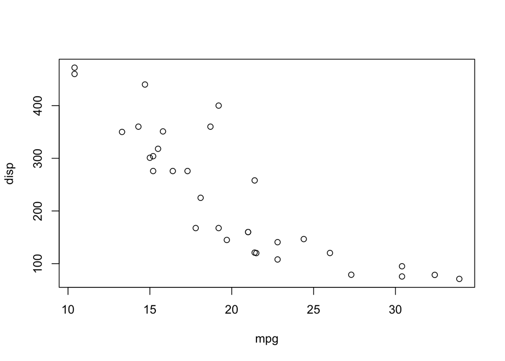

```r
  plot(mpg,disp)
```

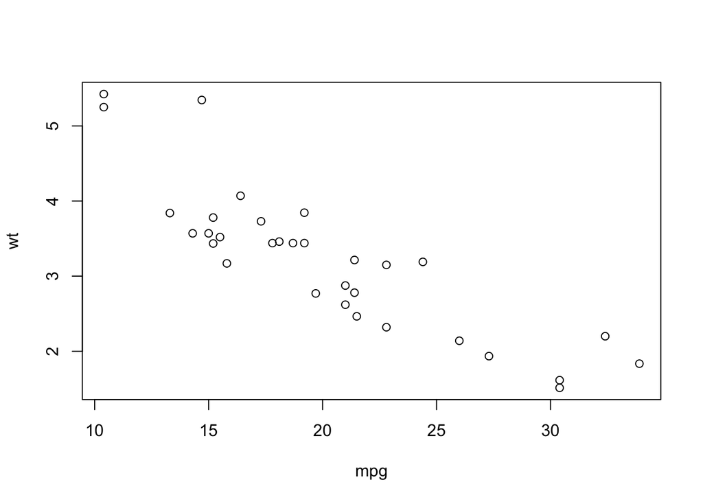

```r
  plot(mpg,wt)
```

```r
detach(mtcars)
```

类似于矩阵的操作 * cbind() * rbind() * dim() * subset() * apply()

#### 数据框的合并

merge()

merge(x, y, by = intersect(names(x), names(y)), by.x = by, by.y = by, all = FALSE, all.x = all, all.y = all, sort = TRUE, suffixes = c(“.x”,“.y”), no.dups = TRUE, incomparables = NULL, …)

```r
d1 <- data.frame(kids=c("Jack","Jill","Jillian","John"),states = c("CA","MA","MA","HI"))
d1
```

```
##      kids states
## 1    Jack     CA
## 2    Jill     MA
## 3 Jillian     MA
## 4    John     HI
```

```r
d2 <- data.frame(ages=c(10,7,12),kids=c("Jill","Lillian","Jack"))
d2
```

```
##   ages    kids
## 1   10    Jill
## 2    7 Lillian
## 3   12    Jack
```

```r
merge(d1,d2)
```

```
##   kids states ages
## 1 Jack     CA   12
## 2 Jill     MA   10
```

```r
merge(d1,d2,by.x="kids")
```

```
##   kids states ages
## 1 Jack     CA   12
## 2 Jill     MA   10
```

```r
merge(d1,d2,by.y = "ages")
```

```
## [1] kids   states kids.y
## <0 rows> (or 0-length row.names)
```

```r
merge(d1,d2,all=T)
```

```
##      kids states ages
## 1    Jack     CA   12
## 2    Jill     MA   10
## 3 Jillian     MA   NA
## 4    John     HI   NA
## 5 Lillian   <NA>    7
```

### 5.因子

```r
status
```

```
## [1] "Poor"      "Improved"  "Excellent" "Poor"
```

```r
factor(status)
```

```
## [1] Poor      Improved  Excellent Poor
## Levels: Excellent Improved Poor
```

```r
factor(status,ordered=TRUE,levels = c("Poor","Improved","Excellent"))
```

```
## [1] Poor      Improved  Excellent Poor
## Levels: Poor < Improved < Excellent
```

#### tapply

和apply类似，分组使用了因子的不同水平为标准

```r
ages <- c(25,26,55,37,21,42)
affils <- c("R","D","D","R","U","D")
tapply(ages,affils,mean)
```

```
##  D  R  U
## 41 31 21
```

### 6.String

x <- c(“I”,“M”)

y <- c(“P”,“C”)

| Strings | results |
| --- | --- |
| paste(x,y,sep =’ ’) | “I P” “M C” |
| paste(x,collapse=’ ’) | “I M” |
| grep(“M”,x) | 2 |
| gsub(“M”,“A”,x) | “I” “A” |
| toupper(x) | “I” “M” |
| tolower(x) | “i” “m” |
| nchar(x) | 1 1 |